# R Bootcamp day 3 Reproducible Research (part 1)

[figure not shown]

[**George G. Vega Yon**](https://ggvy.cl)  
vegayon@usc.edu  
University of Southern California  
Department of Preventive Medicine

August 15th, 2018

# Reproducible Research

> “The term reproducible research refers to the idea that the ultimate product of academic research is the paper along with the **full computational environment used to produce the results in the paper such as the code, data, etc.** that can be used to reproduce the results and **create new work based on the research**”

[Wiki](https://en.wikipedia.org/wiki/Reproducibility#Reproducible_research)

# Reproducible Research (cont. II)

A major new issue in sciences (overall):

- Accessible Reproducible Research ([Mesirov, **Science** 2010](http://science.sciencemag.org/content/327/5964/415))
- Again, and Again, and Again, … ([Jasny et al., **Science** 2011](http://science.sciencemag.org/content/334/6060/1225))
- Challenges in Irreproducible Research ([**nature** topic](http://www.nature.com/news/reproducibility-1.17552))
- Reproducibility of computational workflows is automated using continuous analysis ([Beaulieu-Jones & Greene, **nature biotechnology** 2017](https://www.nature.com/articles/nbt.3780?foxtrotcallback=true))

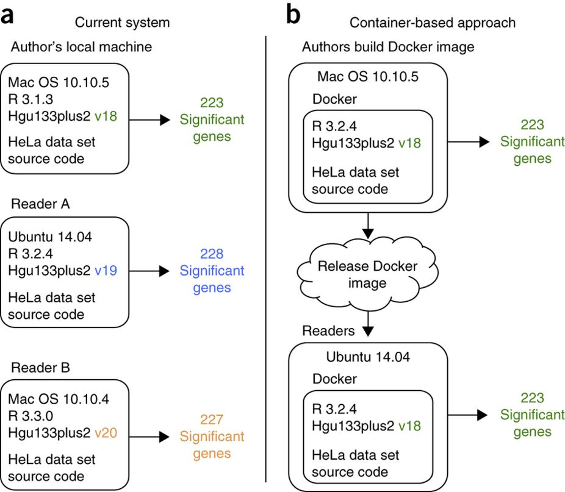

Figure 2 : Research computing versus container-based approaches for differential gene expression analysis of HeLa cells. (source: Reproducibility of computational workflows is automated using continuous analysis)

# How to ‘Reproducible Research’

- What you can do:
  - Provide **raw** data (raw, i.e. before “cleaning it”),
  - Provide source code (what ever programming environment you are using) for reproducing: *cleaned data*, models, tables, figures, etc.
  - Hopefully have a neat way of coding your programs: Inline Comments, Indentation of control-flow statements (for, while, case, switch, ifelse, etc.)
- What else
  - Try using version control software (such as git) to make your research “opensource”
  - Avoid using proprietary software (hopefully always)
  - Try using something like [Docker](https://docker.com)
- More resources at CRAN task View [Reproducible Research](https://cran.r-project.org/web/views/ReproducibleResearch.html)

# Some Refs. on Reproducible Research

- **JAMA** On the “Statistical Analysis Subsection”

  > “[I]nclude the statistical software used to perform the analysis, including the version and manufacturer, along with any extension packages […]”" (see [here](http://jama.jamanetwork.com/public/instructionsForAuthors.aspx#ManuscriptChecklist))
- **Prevention Science** On the “Ethical Responsibilities of Authors”

  > “Upon request authors should be prepared to send relevant documentation or data in order to verify the validity of the results. This could be in the form of raw data, samples, records, etc.” (see [here](http://www.springer.com/cda/content/document/cda_downloaddocument/SPR+Prevention+Science+-+IFAs+-+2015+SL.pdf?SGWID=0-0-45-1514983-p35521857))
- **Health Psychology** On “Computer Code”

  > “We request that runnable source code be included as supplemental material to the article”
- **Annals of Behavioral Medicine** On “Ethical Responsibilities of Authors”

  > “Upon request authors should be prepared to send relevant documentation or data in order to verify the validity of the results. This could be in the form of raw data, samples, records, etc.” (see [here](http://www.springer.com/medicine/journal/12160?detailsPage=pltci_2363800))